# Writing narratives with data: An introduction to ggplot!

Katie Jolly

November 11, 2017

# Setting up our project

I’m a huge fan of nonfiction books and documentaries. I’ve never loved a lot of the big Hollywood movies, but I do enjoy biopics. I find that they give me a good amount of the nonfiction that I enjoy and the drama that makes a blockbuster hit. But, I often find myself a little disappointed in the breadth of biopics available. Most feature a pretty narrow demographic group: straight, white men. Fivethirtyeight did a nice story on this pattern and published the data they used. So, we are going to use that data to write our own story with ggplot! We will start by recreating the graphics from the article [‘Straight Outta Compton’ is the rare biopic not about white dudes](https://fivethirtyeight.com/features/straight-outta-compton-is-the-rare-biopic-not-about-white-dudes/) and then make some of our own!

### Assumed knowledge

In this activity I’ve assumed a few things about your comfort level with R and RStudio, although I’ve designed it to be accessible to everyone. I assume you’ve at least seen the following things before:

- RMarkdown (for presenting your work)
- Packages (for a wider selection of functions)

If these are new to you, I’d suggest taking a look at the [RMarkdown cheat sheet](https://www.rstudio.com/wp-content/uploads/2015/02/rmarkdown-cheatsheet.pdf) to learn more about the markdown structure and this [R Packages article](https://www.datacamp.com/community/tutorials/r-packages-guide) to learn about using packages.

There are times when I mention things about data wrangling (or preparing your data for analysis). I don’t assume knowledge of `dplyr` so I’ve provided code for you to use. If you’re interested in learning more, try reading this [data wrangling cheat sheet](https://www.rstudio.com/wp-content/uploads/2015/02/data-wrangling-cheatsheet.pdf) or trying this [dplyr tutorial for beginners](http://genomicsclass.github.io/book/pages/dplyr_tutorial.html). If you want to test your use of dplyr, try checking out my [dplyr tutorial with bikeshare data](http://katiejolly.io/bikeshare-dplyr/)!

### Packages needed

First, we’ll need to install a few packages. The`tidyverse` package includes both `readr` and `ggplot2`, two of the packages we will be using.

```r
library(tidyverse)
library(ggthemes)
```

### Data from the web

Fivethirtyeight publishes a lot of the data they use on github! We’re going to use their `biopics` data. Fivethirtyeight data is also available in an R package call `fivethirtyeight` but I learned by using their github repo, so that’s the method I prefer. Either way will get you the same data!

```r
# read in the data from github

biopics <- read_csv("https://raw.githubusercontent.com/fivethirtyeight/data/master/biopics/biopics.csv")
```

```r
# if you want to use the R package

library(fivethirtyeight)

data(biopics)
```

### Structure of the data

```r
# I find glimpse to be a more readable version of head/str

glimpse(biopics)
```

```
## Observations: 761
## Variables: 14
## $ title              <chr> "10 Rillington Place", "12 Years a Slave", ...
## $ site               <chr> "http://www.imdb.com/title/tt0066730/", "ht...
## $ country            <chr> "UK", "US/UK", "US/UK", "Canada", "US", "US...
## $ year_release       <int> 1971, 2013, 2010, 2014, 1998, 2008, 2002, 2...
## $ box_office         <chr> "-", "$56.7M", "$18.3M", "-", "$537K", "$81...
## $ director           <chr> "Richard Fleischer", "Steve McQueen", "Dann...
## $ number_of_subjects <int> 1, 1, 1, 1, 1, 1, 1, 1, 1, 2, 2, 1, 3, 3, 3...
## $ subject            <chr> "John Christie", "Solomon Northup", "Aron R...
## $ type_of_subject    <chr> "Criminal", "Other", "Athlete", "Other", "O...
## $ race_known         <chr> "Unknown", "Known", "Unknown", "Known", "Un...
## $ subject_race       <chr> NA, "African American", NA, "White", NA, "A...
## $ person_of_color    <int> 0, 1, 0, 0, 0, 1, 0, 1, 0, 0, 0, 0, 0, 0, 0...
## $ subject_sex        <chr> "Male", "Male", "Male", "Male", "Male", "Ma...
## $ lead_actor_actress <chr> "Richard Attenborough", "Chiwetel Ejiofor",...
```

# Visualizations

## Notes about `ggplot`

ggplot adheres to the “grammar of graphics” (hence the gg!), or the idea that graphics should have a standard structure the same way that language does. The idea is to allow people to use the standard structure of plots to move beyond standard graphics. It was largely popularized by Hadley Wickham after being introduced by Leland Wilkinson in 1999. In 2016, `ggplot2` was the fifth most downloaded package for `R`.

Essentially the grammar of graphics uses layering to create plots. You first start with your mapping of which variables map to which `aesthetics` on your plot. Then you specify the `geom` or method of displaying the data, such as a point or bar. After that you get into the design elements. That’s of course a very brief overview, but you’ll see how we can use that structure in this tutorial!

A great resource for `ggplot` is this [Cheat Sheet](https://www.rstudio.com/wp-content/uploads/2015/03/ggplot2-cheatsheet.pdf) and as with everything else in R, a little googling will get you a long way.

## Looking at race

We will eventually create this graph!

[figure not shown]

First, we need to decide what variable maps to each aesthetic. In `ggplot`, aesthetics are essentially how variables are mapped to something visual, such as an axis or the color.

#### Setting up the axes

To start we need to calculate totals for each racial group in each year. But right now, our `subject_race` variable doesn’t quite tell us the information we want. We can combine the information from `race_known` and `subject_race` to get a variable with three levels: `Unknown`, `White subjects`, and `Nonwhite subjects`.

```r
biopics <- biopics %>% # start with our original data
  mutate(race_plotting = ifelse(race_known == "Unknown", "Unknown", ifelse(subject_race == "White", "White subjects", "Nonwhite subjects"))) # this says, if race_known is unknown, stop there and just mark unknown. But if we know the race, check to see if the race is coded as white. If it is, mark white and stop there. If not, mark nonwhite.

race_plot <- biopics %>%
  group_by(year_release, race_plotting) %>% # we want our calculation of the total to be per racial group, per year
  summarize(total = n()) # count up the observations in each group!

race_plot$race_plotting <- factor(race_plot$race_plotting, levels = c("White subjects", "Nonwhite subjects", "Unknown")) # change around the order of our factor levels for plotting purposes
```

In this graph, it loots like a `count` of total movies is the `y axis` and `year_release` is mapped to the `x axis`.

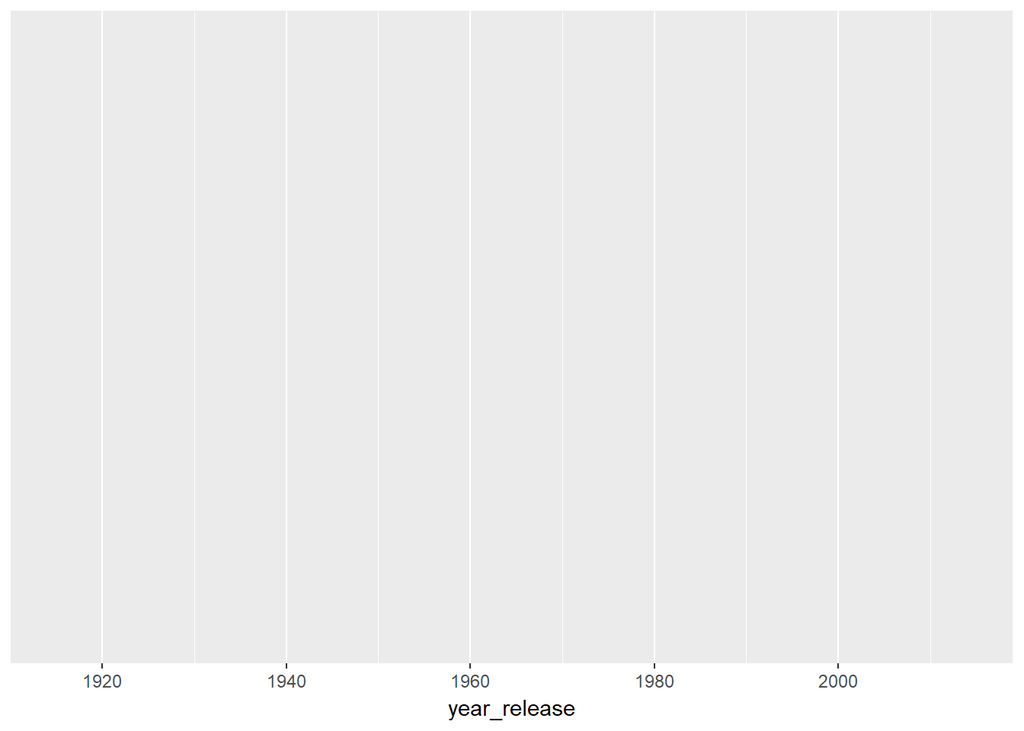

```r
# first we need to create a variable for that!

ggplot(data = race_plot, aes(x= year_release)) # setting our x axis to year_release from the biopics table
```

Nice! Now we have the beginnings of a plot.

#### Adding a geom layer

Next, we need to add our `geom` layer. This is what the shapes on your plot are (line, point, bar, …..). We are using `geom_bar`!

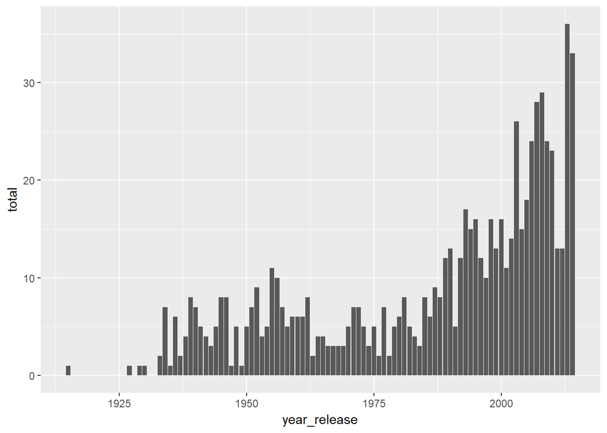

```r
ggplot(data = race_plot, aes(x = year_release, y = total)) +
  geom_bar(stat = "identity") # stat="identity" argument allows us to map to a y aesthetic with geom_bar!
```

#### Adding colors!

In the fivethirtyeight plot, colors correspond to whether or not the subject was white. We will modify our plot to show that as well (and try to pick the same colors in the process)!

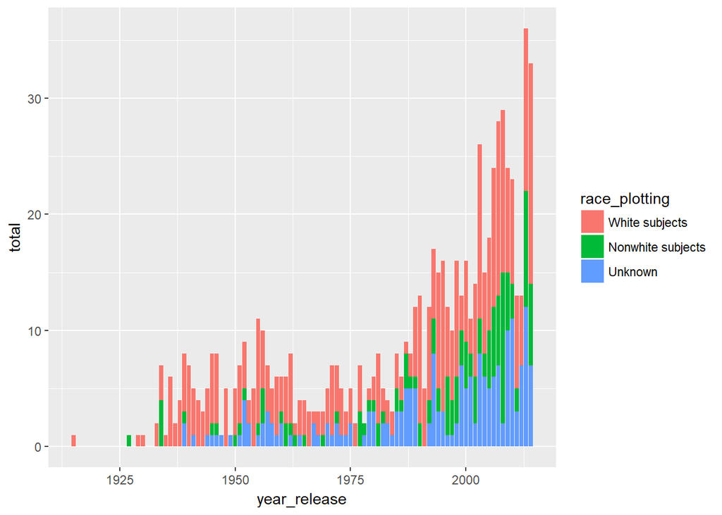

```r
ggplot(data = race_plot, aes(x= year_release, y = total)) +
  geom_bar(aes(fill = race_plotting), stat = "identity")
```

Closer! Now let’s add a title, subtitle, and axis labels! One quick note about the subtitle: `fivethirtyeight` filtered out some of their data. We have 761 biopics in this data so that’s the value we will use instead of 676.